# Final Project: How Andrew McCutchen lost his mojo (and why we are all convinced it’s because he cut his hair)

Leah Hunt

### Introduction:

In this project, we will be looking at the change in Andrew McCutchen’s performance, primarily offensively and during his career with the Pirates. Our central question is how his statistics changed between the 2014 and 2015 seasons (i.e. when he cut his hair) and what factors may have contributed to his decline as a player.

### Clean Up Environment and Useful imports:

```r
rm(list = ls())
library('tidyverse')
library('mosaic')
library('DataComputing')
library(rvest)
library(party)
```

### Scraping the Data:

Let’s start simple with a table shown McCutchen’s statistics broken down by year and team.

```r
page <-
  "https://www.baseball-reference.com/players/m/mccutan01-bat.shtml"
aggregateStats <-
  page %>%
  read_html() %>%
  html_nodes(css = "table") %>%
  html_table(fill = TRUE)
head(aggregateStats[[1]])
```

|  | Year | Age | Tm | Lg | G | PA | AB | R | H | 2B | 3B | HR | RBI | SB | CS | BB | SO | BA | OBP | SLG | OPS | OPS+ | TB | GDP | HBP | SH | SF | IBB | Pos | … |
| --- | --- | --- | --- | --- | --- | --- | --- | --- | --- | --- | --- | --- | --- | --- | --- | --- | --- | --- | --- | --- | --- | --- | --- | --- | --- | --- | --- | --- | --- | --- |
| 1 | 2005 | 18 | PIT-min | Rk,A- | 58 | 254 | 210 | 48 | 65 | 12 | 4 | 2 | 35 | 17 | 2 | 37 | 30 | 0.310 | 0.419 | 0.433 | 0.852 | NA | 91 | 3 | 4 | 1 | 2 | 0 |  | … |
| 2 | 2006 | 19 | PIT-min | A,AA | 134 | 590 | 531 | 89 | 156 | 24 | 4 | 17 | 74 | 23 | 8 | 50 | 111 | 0.294 | 0.359 | 0.450 | 0.809 | NA | 239 | 10 | 6 | 0 | 3 | 3 |  | … |
| 3 | 2007 | 20 | PIT-min | AA,AAA | 135 | 570 | 513 | 77 | 136 | 24 | 3 | 11 | 53 | 21 | 4 | 48 | 94 | 0.265 | 0.329 | 0.388 | 0.717 | NA | 199 | 10 | 3 | 2 | 4 | 1 |  | … |
| 4 | 2008 | 21 | PIT-min | AAA | 135 | 590 | 512 | 75 | 145 | 26 | 3 | 9 | 50 | 34 | 19 | 68 | 87 | 0.283 | 0.372 | 0.398 | 0.770 | NA | 204 | 8 | 6 | 1 | 3 | 1 |  | … |
| 5 | 2009 | 22 | PIT-min | AAA | 49 | 219 | 201 | 41 | 61 | 10 | 8 | 4 | 20 | 10 | 2 | 17 | 24 | 0.303 | 0.361 | 0.493 | 0.853 | NA | 99 | 0 | 1 | 0 | 0 | 0 |  | … |
| 6 | 2009 | 22 | PIT | NL | 108 | 493 | 433 | 74 | 124 | 26 | 9 | 12 | 54 | 22 | 5 | 54 | 83 | 0.286 | 0.365 | 0.471 | 0.836 | 121 | 204 | 3 | 2 | 0 | 4 | 2 | 8 | … |

This looks all fine, but check out the tail!

```r
tail(aggregateStats[[1]])
```

|  | Year | Age | Tm | Lg | G | PA | AB | R | H | 2B | 3B | HR | RBI | SB | CS | BB | SO | BA | OBP | SLG | OPS | OPS+ | TB | GDP | HBP | SH | SF | IBB | Pos | … |
| --- | --- | --- | --- | --- | --- | --- | --- | --- | --- | --- | --- | --- | --- | --- | --- | --- | --- | --- | --- | --- | --- | --- | --- | --- | --- | --- | --- | --- | --- | --- |
| 23 | SFG (1 yr) | SFG (1 yr) | SFG (1 yr) | SFG (1 yr) | 130 | 568 | 482 | 65 | 123 | 28 | 2 | 15 | 55 | 13 | 6 | 73 | 123 | 0.255 | 0.357 | 0.415 | 0.772 | 115 | 200 | 11 | 7 | 0 | 6 | 1 |  | … |
| 24 | PHI (1 yr) | PHI (1 yr) | PHI (1 yr) | PHI (1 yr) | 59 | 262 | 219 | 45 | 56 | 12 | 1 | 10 | 29 | 2 | 1 | 43 | 55 | 0.256 | 0.378 | 0.457 | 0.834 | 115 | 100 | 1 | 0 | 0 | 0 | 0 |  | … |
| 25 | NYY (1 yr) | NYY (1 yr) | NYY (1 yr) | NYY (1 yr) | 25 | 114 | 87 | 18 | 22 | 2 | 1 | 5 | 10 | 1 | 3 | 22 | 22 | 0.253 | 0.421 | 0.471 | 0.892 | 145 | 41 | 1 | 4 | 0 | 1 | 0 |  | … |
| 26 |  |  |  |  | NA | NA | NA | NA | NA | NA | NA | NA | NA | NA | NA | NA | NA | NA | NA | NA | NA | NA | NA | NA | NA | NA | NA | NA |  | … |
| 27 | NL (11 yrs) | NL (11 yrs) | NL (11 yrs) | NL (11 yrs) | 1535 | 6659 | 5734 | 924 | 1642 | 332 | 47 | 228 | 809 | 186 | 74 | 801 | 1216 | 0.286 | 0.377 | 0.480 | 0.857 | 134 | 2752 | 93 | 68 | 3 | 53 | 64 |  | … |
| 28 | AL (1 yr) | AL (1 yr) | AL (1 yr) | AL (1 yr) | 25 | 114 | 87 | 18 | 22 | 2 | 1 | 5 | 10 | 1 | 3 | 22 | 22 | 0.253 | 0.421 | 0.471 | 0.892 | 145 | 41 | 1 | 4 | 0 | 1 | 0 |  | … |

Holy untidy data Batman! The table includes a bunch of totals at the end that summarise the previous data. As it turns out, using the View function we can find that we really only want the first 18 rows.

```r
stats_by_season <-
  aggregateStats[[1]][1:18,]
tail(stats_by_season)
```

|  | Year | Age | Tm | Lg | G | PA | AB | R | H | 2B | 3B | HR | RBI | SB | CS | BB | SO | BA | OBP | SLG | OPS | OPS+ | TB | GDP | HBP | SH | SF | IBB | Pos | … |
| --- | --- | --- | --- | --- | --- | --- | --- | --- | --- | --- | --- | --- | --- | --- | --- | --- | --- | --- | --- | --- | --- | --- | --- | --- | --- | --- | --- | --- | --- | --- |
| 13 | 2016 | 29 | PIT | NL | 153 | 675 | 598 | 81 | 153 | 26 | 3 | 24 | 79 | 6 | 7 | 69 | 143 | 0.256 | 0.336 | 0.430 | 0.766 | 104 | 257 | 15 | 5 | 0 | 3 | 7 | *8 | … |
| 14 | 2017 | 30 | PIT | NL | 156 | 650 | 570 | 94 | 159 | 30 | 2 | 28 | 88 | 11 | 5 | 73 | 116 | 0.279 | 0.363 | 0.486 | 0.849 | 123 | 277 | 10 | 4 | 0 | 3 | 5 | *89/D | … |
| 15 | 2018 | 31 | TOT | MLB | 155 | 682 | 569 | 83 | 145 | 30 | 3 | 20 | 65 | 14 | 9 | 95 | 145 | 0.255 | 0.368 | 0.424 | 0.792 | 120 | 241 | 12 | 11 | 0 | 7 | 1 | *97/D | … |
| 16 | 2018 | 31 | SFG | NL | 130 | 568 | 482 | 65 | 123 | 28 | 2 | 15 | 55 | 13 | 6 | 73 | 123 | 0.255 | 0.357 | 0.415 | 0.772 | 115 | 200 | 11 | 7 | 0 | 6 | 1 | *9/D | … |
| 17 | 2018 | 31 | NYY | AL | 25 | 114 | 87 | 18 | 22 | 2 | 1 | 5 | 10 | 1 | 3 | 22 | 22 | 0.253 | 0.421 | 0.471 | 0.892 | 145 | 41 | 1 | 4 | 0 | 1 | 0 | 97/D | … |
| 18 | 2019 | 32 | PHI | NL | 59 | 262 | 219 | 45 | 56 | 12 | 1 | 10 | 29 | 2 | 1 | 43 | 55 | 0.256 | 0.378 | 0.457 | 0.834 | 115 | 100 | 1 | 0 | 0 | 0 | 0 | 78/D | … |

But this isn’t the end of our tidy data problems! The last two columns are also untidy. The last column shows any awards he won in the year. While this would likely correlate with his performance, we would expect the awards he recieved to be caused by his performance as opposed to the other way around, so we can pretty safely ignore that column. The positions he played, however, could be interesting. These are represented in the second to last column but are coded into strings of characters. The characters can be decoded as follows: numbers represent positions (by standard convention), * indicates that the position was played in at least 2/3 of games, / indicates that the position was played less than 10 games, and D indicates being the DH (designated hitter).

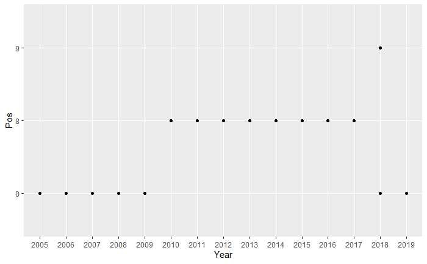

```r
stats_by_season %>%
  mutate(Pos = ifelse(grepl("\\*.", Pos), substring(Pos, 2, 2), 0)) %>%  # Makes use of the fact that primary positions are  listed first and are unique if they exist
  ggplot(aes(x = Year, y = Pos)) +
    geom_point()
```

To help us figure out which factors may be helpful to consider, let’s get a little intuition about the year by year stats. Let’s look at 4 major measures of batting performance: BA, OBP, OPS, and slugging percentage.

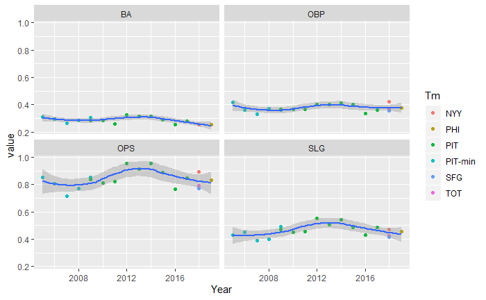

```r
stats_by_season %>%
  gather(key = type, value = value, BA, OBP, OPS, SLG) %>%   # We have to gather the BA, OBP, OPS, and SLG in order to use them for faceting
  ggplot(aes(x = as.numeric(Year), y = value)) +
    geom_point(aes(color = Tm))+
    facet_wrap(~ type, ncol = 2)+
    stat_smooth() + xlab("Year")
```

We notice that all four of these have similar shape, so it is fair to assume that we can narrow down to just one or two. (For this analysis, we will focus on BA and OBP since they are the simplest to calculate and most widely known.)

Many Pirates fans could have predicted the basic shape these graphs would take, but the question we are interested in is why they all seem to peak around 2014. To the casual observer, there is one obvious thing that changed between 2014 and 2015: he cut his hair and obviously then lost his mojo because of it. As appealing as this explanation may be, let’s see if we can find any other factors that may attribute to the changes in performance.

The most obvious factor that may come to mind is that he also got married between these two seasons. While this factor will not be considered in this analysis, in other analyses, marriage has not been shown to correlate with worse performance (see: [http://ftp.iza.org/dp5695.pdf]).

### Peak ages of MLB players

To see how age may be playing a role in performance, let’s get data from more MLB players to compare McCutchen’s performance by age.

```r
id <-
  "10PK1Kne2e2shLERd3y19DGU7VcXhPmcB" # google file ID
allPlayers <-
  read.csv(sprintf("https://docs.google.com/uc?id=%s&export=download", id))
glimpse(allPlayers)
```

```
Observations: 105,861
Variables: 22
$ playerID <fct> abercda01, addybo01, allisar01, allisdo01, ansonca01, armstbo01, barkeal01, barnero01, barrebi01, ba...
$ yearID   <int> 1871, 1871, 1871, 1871, 1871, 1871, 1871, 1871, 1871, 1871, 1871, 1871, 1871, 1871, 1871, 1871, 1871...
$ stint    <int> 1, 1, 1, 1, 1, 1, 1, 1, 1, 1, 1, 1, 1, 1, 1, 1, 1, 1, 1, 1, 1, 1, 1, 1, 1, 1, 1, 1, 1, 1, 1, 1, 1, 1...
$ teamID   <fct> TRO, RC1, CL1, WS3, RC1, FW1, RC1, BS1, FW1, BS1, CL1, CL1, WS3, TRO, PH1, TRO, PH1, PH1, WS3, FW1, ...
$ lgID     <fct> NA, NA, NA, NA, NA, NA, NA, NA, NA, NA, NA, NA, NA, NA, NA, NA, NA, NA, NA, NA, NA, NA, NA, NA, NA, ...
$ G        <int> 1, 25, 29, 27, 25, 12, 1, 31, 1, 18, 22, 1, 10, 3, 20, 29, 1, 1, 17, 1, 25, 29, 30, 3, 12, 19, 29, 1...
$ AB       <int> 4, 118, 137, 133, 120, 49, 4, 157, 5, 86, 89, 3, 36, 15, 94, 128, 4, 4, 73, 2, 106, 152, 134, 14, 63...
$ R        <int> 0, 30, 28, 28, 29, 9, 0, 66, 1, 13, 18, 0, 6, 7, 24, 26, 0, 0, 17, 0, 19, 51, 24, 2, 11, 16, 31, 17,...
$ H        <int> 0, 32, 40, 44, 39, 11, 1, 63, 1, 13, 27, 0, 7, 6, 33, 32, 0, 1, 17, 0, 28, 46, 30, 1, 15, 20, 32, 20...
$ X2B      <int> 0, 6, 4, 10, 11, 2, 0, 10, 1, 2, 1, 0, 0, 0, 9, 3, 0, 0, 1, 0, 2, 3, 4, 0, 2, 2, 8, 3, 0, 8, 7, 0, 1...
$ X3B      <int> 0, 0, 5, 2, 3, 1, 0, 9, 0, 1, 10, 0, 0, 0, 1, 3, 0, 0, 1, 0, 5, 3, 0, 0, 3, 0, 1, 1, 0, 1, 5, 1, 1, ...
$ HR       <int> 0, 0, 0, 2, 0, 0, 0, 0, 0, 0, 3, 0, 0, 0, 1, 0, 0, 0, 0, 0, 0, 0, 0, 0, 1, 0, 0, 0, 0, 0, 3, 0, 0, 0...
$ RBI      <int> 0, 13, 19, 27, 16, 5, 2, 34, 1, 11, 18, 0, 1, 5, 21, 23, 0, 0, 8, 0, 13, 24, 21, 0, 14, 10, 18, 16, ...
$ SB       <int> 0, 8, 3, 1, 6, 0, 0, 11, 0, 1, 0, 0, 2, 2, 4, 4, 0, 0, 3, 0, 1, 6, 4, 0, 0, 5, 2, 12, 0, 6, 16, 0, 0...
$ CS       <int> 0, 1, 1, 1, 2, 1, 0, 6, 0, 0, 1, 0, 0, 0, 0, 4, 0, 0, 1, 0, 0, 0, 0, 0, 0, 0, 1, 1, 0, 3, 2, 0, 0, 4...
$ BB       <int> 0, 4, 2, 0, 2, 0, 1, 13, 0, 0, 3, 1, 2, 0, 2, 9, 0, 0, 4, 1, 3, 4, 7, 0, 1, 2, 8, 8, 0, 3, 10, 2, 1,...
$ SO       <int> 0, 0, 5, 2, 1, 1, 0, 1, 0, 0, 4, 0, 0, 0, 2, 2, 3, 0, 2, 0, 2, 4, 2, 0, 1, 1, 3, 2, 0, 0, 2, 0, 2, 2...
$ IBB      <int> NA, NA, NA, NA, NA, NA, NA, NA, NA, NA, NA, NA, NA, NA, NA, NA, NA, NA, NA, NA, NA, NA, NA, NA, NA, ...
$ HBP      <int> NA, NA, NA, NA, NA, NA, NA, NA, NA, NA, NA, NA, NA, NA, NA, NA, NA, NA, NA, NA, NA, NA, NA, NA, NA, ...
$ SH       <int> NA, NA, NA, NA, NA, NA, NA, NA, NA, NA, NA, NA, NA, NA, NA, NA, NA, NA, NA, NA, NA, NA, NA, NA, NA, ...
$ SF       <int> NA, NA, NA, NA, NA, NA, NA, NA, NA, NA, NA, NA, NA, NA, NA, NA, NA, NA, NA, NA, NA, NA, NA, NA, NA, ...
$ GIDP     <int> 0, 0, 1, 0, 0, 0, 0, 1, 0, 0, 0, 0, 2, 0, 1, 2, 0, 0, 0, 0, 3, 1, 1, 0, 0, 0, 3, 1, 0, 3, 1, 0, 0, 0...
```

In order to find age, we are also going to need the birth years of players, which we can use this next dataset for.

```r
playerIDs <-
  read.csv(sprintf("https://docs.google.com/uc?id=%s&export=download", '187HgaVhV0-ADZm5GY4ZhnVDjw2Fzrc8F'))
glimpse(playerIDs)
```

```
Observations: 19,617
Variables: 24
$ playerID     <fct> aardsda01, aaronha01, aaronto01, aasedo01, abadan01, abadfe01, abadijo01, abbated01, abbeybe01, ...
$ birthYear    <int> 1981, 1934, 1939, 1954, 1972, 1985, 1850, 1877, 1869, 1866, 1862, 1874, 1951, 1972, 1967, 1969, ...
$ birthMonth   <int> 12, 2, 8, 9, 8, 12, 11, 4, 11, 10, 3, 10, 2, 8, 9, 6, 2, 9, 9, 7, 1, 7, 1, 9, 10, 3, 2, 8, 10, 6...
$ birthDay     <int> 27, 5, 5, 8, 25, 17, 4, 15, 11, 14, 16, 22, 16, 17, 19, 2, 18, 5, 15, 31, 2, 15, 30, 23, 30, 6, ...
$ birthCountry <fct> USA, USA, USA, USA, USA, D.R., USA, USA, USA, USA, USA, USA, USA, USA, USA, USA, USA, USA, USA, ...
$ birthState   <fct> CO, AL, AL, CA, FL, La Romana, PA, PA, VT, NE, OH, OH, AR, GA, MI, OH, MA, PA, CA, OH, OK, GA, C...
$ birthCity    <fct> Denver, Mobile, Mobile, Orange, Palm Beach, La Romana, Philadelphia, Latrobe, Essex, Falls City,...
$ deathYear    <int> NA, NA, 1984, NA, NA, NA, 1905, 1957, 1962, 1926, 1930, 1935, NA, NA, NA, NA, NA, 1933, NA, 1993...
$ deathMonth   <int> NA, NA, 8, NA, NA, NA, 5, 1, 6, 4, 2, 6, NA, NA, NA, NA, NA, 4, NA, 5, 11, NA, 2, NA, 11, 12, 12...
$ deathDay     <int> NA, NA, 16, NA, NA, NA, 17, 6, 11, 27, 13, 11, NA, NA, NA, NA, NA, 13, NA, 20, 11, NA, 19, NA, 1...
$ deathCountry <fct> , , USA, , , , USA, USA, USA, USA, USA, USA, , , , , , USA, , USA, USA, , USA, , USA, USA, USA, ...
$ deathState   <fct> , , GA, , , , NJ, FL, VT, CA, MI, CA, , , , , , DC, , OH, PA, , CA, , NC, NC, KY, CA, TX, , FL, ...
$ deathCity    <fct> , , Atlanta, , , , Pemberton, Fort Lauderdale, Colchester, San Francisco, Ottawa Lake, Los Angel...
$ nameFirst    <fct> David, Hank, Tommie, Don, Andy, Fernando, John, Ed, Bert, Charlie, Dan, Fred, Glenn, Jeff, Jim, ...
$ nameLast     <fct> Aardsma, Aaron, Aaron, Aase, Abad, Abad, Abadie, Abbaticchio, Abbey, Abbey, Abbott, Abbott, Abbo...
$ nameGiven    <fct> David Allan, Henry Louis, Tommie Lee, Donald William, Fausto Andres, Fernando Antonio, John W., ...
$ weight       <int> 215, 180, 190, 190, 184, 220, 192, 170, 175, 169, 190, 180, 200, 190, 200, 180, 200, 165, 185, 1...
$ height       <int> 75, 72, 75, 75, 73, 73, 72, 71, 71, 68, 71, 70, 78, 74, 75, 71, 76, 69, 75, 74, NA, 75, 70, 73, ...
$ bats         <fct> R, R, R, R, L, L, R, R, R, L, R, R, R, R, L, R, L, L, R, L, , R, R, R, R, R, L, R, R, R, L, R, R...
$ throws       <fct> R, R, R, R, L, L, R, R, R, L, R, R, R, L, L, R, L, R, R, L, , R, R, R, L, R, L, R, L, R, L, R, R...
$ debut        <fct> 2004-04-06, 1954-04-13, 1962-04-10, 1977-07-26, 2001-09-10, 2010-07-28, 1875-04-26, 1897-09-04, ...
$ finalGame    <fct> 2015-08-23, 1976-10-03, 1971-09-26, 1990-10-03, 2006-04-13, 2017-10-01, 1875-06-10, 1910-09-15, ...
$ retroID      <fct> aardd001, aaroh101, aarot101, aased001, abada001, abadf001, abadj101, abbae101, abbeb101, abbec1...
$ bbrefID      <fct> aardsda01, aaronha01, aaronto01, aasedo01, abadan01, abadfe01, abadijo01, abbated01, abbeybe01, ...
```

```r
translateIDs <-
  playerIDs[,c("playerID","birthYear", "nameFirst", "nameLast")]
```

Now let’s merge our new datasets.

```r
merged_player_data <- allPlayers %>%
  left_join(translateIDs, by="playerID")
```

```
Column `playerID` joining factors with different levels, coercing to character vector
```

```r
merged_player_data<- merged_player_data %>%  # Merge step
  mutate(age = yearID - birthYear) %>%  # Adds age
  mutate(BA = H /(AB - BB)) %>%  # Adds BA
  mutate(OBP = (BB + H)/AB)  # Adds OBP
```

Now it would be nice to have a way of normalizing the BA and OBP. Let’s do this by taking each BA and OBP as a percentage of that player’s maximum over all seasons they played. From here on out, we will also enforce that a player must have at least 20 at bats in a season to be included.

```r
# Create a data table for maximum batting averages and OBPs
maxOBP<-merged_player_data %>%
  filter(AB>20) %>%  # Forces players to have over 20 ABs to be considered
  group_by(playerID) %>%
  summarise(maxobp = max(OBP))
maxBA<-merged_player_data %>%
  filter(AB > 20) %>%  # Forces players to have over 20 ABs to be considered
  group_by(playerID) %>%
  summarise(maxba = max(BA))
#Uses maxBA and maxOBP to add their data to the full data set
merged_player_data <-
  merged_player_data %>%
  left_join(maxOBP, by = "playerID") %>%
  left_join(maxBA, by = "playerID") %>%
  mutate(BApercent = as.numeric(BA) / as.numeric(maxba)) %>%
  mutate(OBPpercent = as.numeric(OBP) / as.numeric(maxobp))
```

Now let’s see the distribution over all players. Since McCutchen only played from ages 18-32 so far, we can limit our the ages to just those.

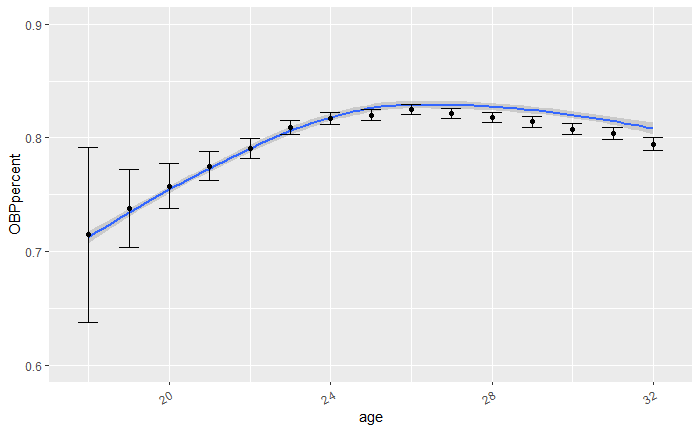

```r
merged_player_data %>%
  filter(AB > 20) %>%  # Forces players to have over 20 ABs to be considered
  group_by(age) %>%
  filter(age > 17 & age < 33) %>%  # Includes only the age range relative to McCutchen
  summarise(se = sd(BApercent, na.rm = TRUE) / sqrt(n()),
            BApercent = mean(BApercent, na.rm = TRUE),
            OBPpercent = mean(OBPpercent, na.rm = TRUE)) %>%
  ggplot(aes(x = age, y = OBPpercent)) +
    geom_smooth() +
    geom_errorbar(aes(x = age,
                      ymax = BApercent + 2 * se,
                      ymin = BApercent - 2 * se,
                      width = 0.5)) +
  geom_point(aes(x = age,
                 y = BApercent)) +
  theme(axis.text.x = element_text(angle = 30, hjust = 1)) +
  ylim(.6, .9)
```

This looks similar to pattern we observed from McCutchen, but it would be helpful to actually show them side-by-side.

### Comparing McCutchen to other MLB players

Now we want to merge our McCutchen data and the general data so that we can compare them. In the process, it would be a good idea to rename all our McCutchen data to make it clear which columns deal with him individually and which ones are overall. (Translation: I tried it without renaming the columns then monumentally confused myself, so we’re just going to rename them.)

```r
# Make sure Age is numeric
stats_by_season <-
  stats_by_season %>%
  mutate(Age = as.numeric(Age))
#loop over column names and change each to add an M (i.e. make the end dataframe WAY easier to read)
stats_by_season_renamed <-
  stats_by_season
for (colname in colnames(stats_by_season)){
  colnames(stats_by_season_renamed)[colnames(stats_by_season) == colname] <-
    paste(colname, '_M', sep = '')
}
merged_player_data_with_McCutchen <-
  merged_player_data %>%
  filter(AB > 20) %>%  # Forces players to have over 20 ABs to be considered
  group_by(age) %>%
  summarise(se = sd(BApercent, na.rm = TRUE) / sqrt(n()),
            BApercent = mean(BApercent, na.rm=TRUE),
            seOBP = sd(OBPpercent, na.rm = TRUE),
            OBPpercent=mean(OBPpercent, na.rm = TRUE))  %>%
  left_join(stats_by_season_renamed, by = c('age'='Age_M'))
merged_player_data_with_McCutchen<-
  merged_player_data_with_McCutchen %>%
  mutate(BApercent_M = as.numeric(BA_M)/.327,  # .327 is McCutchen's max BA
         OBPpercent_M = as.numeric(OBP_M)/.410)  # Because we only consider his time as a Pirate, we use .410 as the max OBP
```

Now that we have merged the tables, let’s see how the two distrbutions compare. In the below plots, we see MCutchen’s performance (one for OBP and one for BA) in blue and the distribution of the average of MLB players in red. The solid black lines show the time he joined and left the Pirates and the dotted line shows the 2014 season, which is where we would expect the peak to be. Note that in defining the maximum value for McCutchen, only statistics in his time with the Pirates were considered.

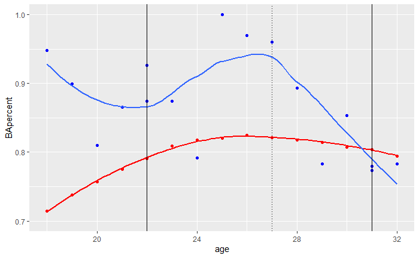

```r
merged_player_data_with_McCutchen %>%
  filter(age > 17 & age < 33) %>%  # Filters out all ages outside McCutchen's age range
  ggplot()  +
    geom_point(aes(x = age, y = BApercent), color = 'red') +
    geom_point(aes(x = age, y = BApercent_M), color = 'blue') +
    stat_smooth(aes(x = age, y = BApercent), color = 'red', se = FALSE) +
    stat_smooth(aes(x = age, y = BApercent_M), se = FALSE) +
    geom_vline(xintercept = 22) +  # When he started with the Pirates
    geom_vline(xintercept = 31) +  # When he left the pirates
    geom_vline(xintercept = 27, linetype = "dotted") +  # 2014 season
    ylim(.7, 1)
```

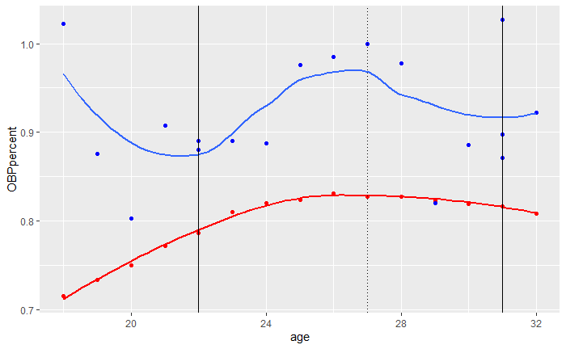

```r
merged_player_data_with_McCutchen %>%
  mutate(difference = OBPpercent_M - OBPpercent) %>%
  filter(age > 17 & age < 33) %>%
  ggplot()  +
    geom_point(aes(x = age, y = OBPpercent), color = 'red') +
    geom_point(aes(x = age, y = OBPpercent_M), color = 'blue') +
    stat_smooth(aes(x = age, y = OBPpercent), color = 'red', se = FALSE) +
    stat_smooth(aes(x = age, y = OBPpercent_M), se = FALSE) +
    geom_vline(xintercept = 22) +  # When he started with the Pirates
    geom_vline(xintercept = 31) +  # When he left the pirates
    geom_vline(xintercept = 27, linetype = "dotted")   # 2014 season
```

It appears that the peaks are similar, but there is a lot more variation in McCutchen’s data and the peak in the general data is not particularly distinct. One way to see the general distribution more distinctly is to instead just consier the peak years of players, which the below plots do. Again, a vertical dotted line is plotted at the equivalence of McCutchen’s 2014 season.

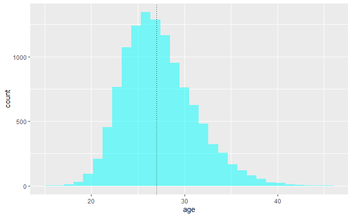

```r
merged_player_data %>%
  filter(AB > 20) %>%  # Forces players to have over 20 ABs to be considered
  filter(OBP == maxobp) %>%
  ggplot() +
    geom_histogram(aes(age), fill = 'cyan', alpha = .5) +
    geom_vline(xintercept = 27, linetype = "dotted")  # equivalent to McCutchen's 2014 season
```

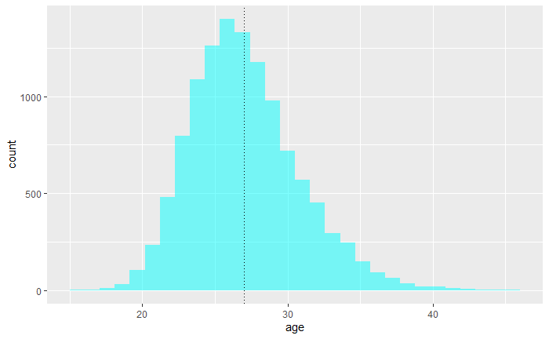

```r
merged_player_data %>%
  filter(AB > 20) %>%  # Forces players to have over 20 ABs to be considered
  filter(BA == maxba) %>%
  ggplot() +
    geom_histogram(aes(age), fill = 'cyan', alpha = .5) +
  geom_vline(xintercept = 27, linetype = "dotted")  # equivalent to McCutchen's 2014 season
```

According to both of these, 2014-2015 would mark right around the average peak time, which supports that it is reasonable to consider age as a factor in McCutchens change in performance.

### Conclusion

Though McCutchen cut his hair, he didn’t lose his mojo; he just got older. While we cannot confirm that this is the only significant factor associated with McCutchen’s performance, it does give evidence that there are factors outside of his hair style that can explain his changes in performance.